# Understanding a Unicorn

Daniel gaza

1/10/2022

```
                                  What Is a Unicorn?
```

A unicorn is a privately held startup company with a valuation of more than $1 billion. It’s popular in the venture capital industry. Aileen Lee, a venture capitalist, popularized the term in 2013. Unicorns are extremely rare and necessitate creativity. Because of their size, unicorn investors are typically private investors or venture capitalists, making them out of reach for retail investors. Although it is not required, many unicorns work their way up to becoming public.

This project will involve working with Unicorn Companies data to answer a series of questions about Unicorn companies. This project’s analysis will be carried out using R.

```r
#Loading Libraries we'll be using for this project
library(tidyverse)
library(lubridate)
```

```r
library(ggplot2)
library(readr)
library(dplyr)
library(tidyr)
```

With Polarity Groups launching a new venture, Polarity Ventures, investing in and funding start-ups, small businesses with impressive growth and high growth potential will be the best bet for breaking into the venture capital world. Unicorn Companies, startups, and small businesses with the potential to become Unicorns are the target market.

This open data set from datacamp.com was discovered during one of our research projects. This data set will be used to determine what kind of market we are entering and what to look for and off when evaluating a business.

The following are the questions that will be addressed in this project:

• Which Unicorn Companies have had the biggest return on investments?

• How long does it usually take for a company to become a unicorn? Has it always been this way?

• Which countries have the most unicorns? Are there any cities that appear to be industry hubs?

• Which investors have funded the most unicorns?

The dataset contains a record of private companies with a valuation of more than $1 billion as of March 2022, including each company’s current valuation, funding, country of origin, industry, select investors, and the years it was founded and became a unicorn.

```r
#Loading dataset a csv file, and assigning date to date datatype
Unicorn_Companies <- data.frame(read_csv("Unicorn_Companies.csv", #setting date in date datatype
                              col_types = cols(Date_Joined = col_date(format = "%m/%d/%Y"))))
head(Unicorn_Companies)
```

|  | Company | Valuation | Date_Joined | Industry | City | Country | Continent | Year_Founded | Funding | Select_Investors |
| --- | --- | --- | --- | --- | --- | --- | --- | --- | --- | --- |
| 1 | Bytedance | $180B | 2017-04-07 | Artificial intelligence | Beijing | China | Asia | 2012 | $8B | Sequoia Capital China, SIG Asia Investments, Sina Weibo, Softbank Group |
| 2 | SpaceX | $100B | 2012-12-01 | Other | Hawthorne | United States | North America | 2002 | $7B | Founders Fund, Draper Fisher Jurvetson, Rothenberg Ventures |
| 3 | SHEIN | $100B | 2018-07-03 | E-commerce & direct-to-consumer | Shenzhen | China | Asia | 2008 | $2B | Tiger Global Management, Sequoia Capital China, Shunwei Capital Partners |
| 4 | Stripe | $95B | 2014-01-23 | Fintech | San Francisco | United States | North America | 2010 | $2B | Khosla Ventures, LowercaseCapital, capitalG |
| 5 | Klarna | $46B | 2011-12-12 | Fintech | Stockholm | Sweden | Europe | 2005 | $4B | Institutional Venture Partners, Sequoia Capital, General Atlantic |
| 6 | Canva | $40B | 2018-01-08 | Internet software & services | Surry Hills | Australia | Oceania | 2012 | $572M | Sequoia Capital China, Blackbird Ventures, Matrix Partners |

The data arrived in a format that would have made analysis extremely difficult; a restructuring was required to make the analysis possible; changes such as substituting B (for billions) for actual zeros (000..) and setting appropriate datatypes were required. Symbols and letters must be removed in order to assign an appropriate datatype. NAs in funding are funds invested by investors that are not recorded in the dataset and cannot be accessed from any sources, so NAs were converted to zeros for ease of computation. Data Manipulation

```r
#Resigning Valuation column to appropriate Datatype
#For Valuation
Unicorn_Companies<-mutate(Unicorn_Companies,Valuation = substring(Valuation, 2))
Unicorn_Companies<-mutate(Unicorn_Companies,Valuation=gsub("B","000000000",Unicorn_Companies$Valuation))
Unicorn_Companies<- mutate(Unicorn_Companies,Valuation = as.double(Valuation))

#For Funding
Unicorn_Companies<-mutate(Unicorn_Companies,Funding=gsub("B","000000000",Unicorn_Companies$Funding))
Unicorn_Companies<-mutate(Unicorn_Companies,Funding=gsub("M","000000",Unicorn_Companies$Funding))
Unicorn_Companies<-mutate(Unicorn_Companies,Funding = substring(Funding, 2))
Unicorn_Companies<- mutate(Unicorn_Companies,Funding = as.double(Funding))
#Substituting "NA" to 0, for easy computation.
Unicorn_Companies<-mutate(Unicorn_Companies, Funding = replace(Unicorn_Companies$Funding,is.na(Unicorn_Companies$Funding),0))
head(Unicorn_Companies)
```

|  | Company | Valuation | Date_Joined | Industry | City | Country | Continent | Year_Founded | Funding | Select_Investors |
| --- | --- | --- | --- | --- | --- | --- | --- | --- | --- | --- |
| 1 | Bytedance | 1.8e+11 | 2017-04-07 | Artificial intelligence | Beijing | China | Asia | 2012 | 8.00e+09 | Sequoia Capital China, SIG Asia Investments, Sina Weibo, Softbank Group |
| 2 | SpaceX | 1.0e+11 | 2012-12-01 | Other | Hawthorne | United States | North America | 2002 | 7.00e+09 | Founders Fund, Draper Fisher Jurvetson, Rothenberg Ventures |
| 3 | SHEIN | 1.0e+11 | 2018-07-03 | E-commerce & direct-to-consumer | Shenzhen | China | Asia | 2008 | 2.00e+09 | Tiger Global Management, Sequoia Capital China, Shunwei Capital Partners |
| 4 | Stripe | 9.5e+10 | 2014-01-23 | Fintech | San Francisco | United States | North America | 2010 | 2.00e+09 | Khosla Ventures, LowercaseCapital, capitalG |
| 5 | Klarna | 4.6e+10 | 2011-12-12 | Fintech | Stockholm | Sweden | Europe | 2005 | 4.00e+09 | Institutional Venture Partners, Sequoia Capital, General Atlantic |
| 6 | Canva | 4.0e+10 | 2018-01-08 | Internet software & services | Surry Hills | Australia | Oceania | 2012 | 5.72e+08 | Sequoia Capital China, Blackbird Ventures, Matrix Partners |

The data is now ready for analysis after all necessary cleaning and formatting. Now we will investigate the questions that have been posed for this project; the results are only as good as the questions posed. Data always tells you what you ask it, so no matter how much potential a data has, if you don’t ask the right questions, you won’t get anything useful out of it. To achieve the desired results, four (4) questions were developed for this analysis.

1. Which Unicorn Companies have had the biggest return on investments?

To determine which companies have the highest return on investment, we must first calculate the return on investment (ROI) for all of the companies in the data. By calculating the ROI, we can correctly and accurately determine which companies have the highest return on investment from all investments made on this data set. Naming the column with the results as ROI (Return On investment).

```r
#Creating a table to house return On Investment. Keeping Calculated columns separate from original data
return_on_investment<-Unicorn_Companies%>%
  select(Company,Select_Investors, Funding,Valuation)

#Calculating return on investment (ROI)
ROI<-((Unicorn_Companies$Valuation -Unicorn_Companies$Funding)/Unicorn_Companies$Funding)*100

#Fixing the result into our table
return_on_investment<-mutate(return_on_investment,ROI = round(ROI))#removing decimal point

#filtering to remove Companies without funding,after the calculation their ROI returned as Inf
return_on_investment<-return_on_investment%>%
 filter(ROI != "Inf")%>%
   arrange(desc(ROI))
head(return_on_investment)
```

|  | Company | Select_Investors | Funding | Valuation | ROI |
| --- | --- | --- | --- | --- | --- |
| 1 | Zapier | Sequoia Capital, Bessemer Venture Partners, Threshold Ventures | 1.00e+06 | 4e+09 | 399900 |
| 2 | Dunamu | Qualcomm Ventures, Woori Investment, Hanwha Investment & Securities | 7.10e+07 | 9e+09 | 12576 |
| 3 | Workhuman | ICG | 9.00e+06 | 1e+09 | 11011 |
| 4 | CFGI | The Carlyle Group, CVC Capital Partners | 1.90e+07 | 2e+09 | 10426 |
| 5 | Manner | Coatue Management, H Capital, Capital Today | 1.00e+07 | 1e+09 | 9900 |
| 6 | DJI Innovations | Accel Partners, Sequoia Capital | 1.05e+08 | 8e+09 | 7519 |

```r
# Limiting to Top 10 companies for better presentation
Top.10.ROI<-return_on_investment%>%
  top_n(10)
```

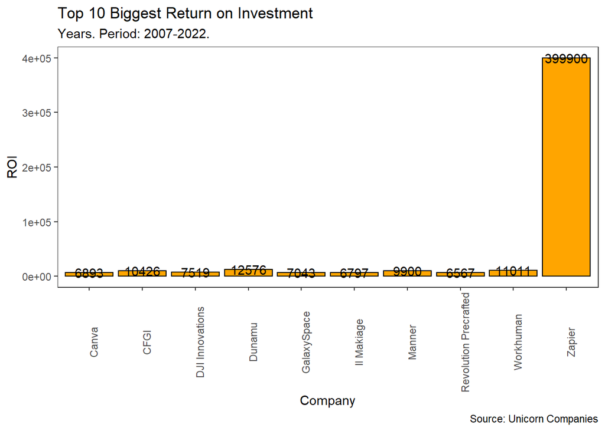

```r
# A bar chart showing what all this code means
ggplot(Top.10.ROI, aes(x=Company, y=ROI))+
  geom_bar(color="black",fill="orange",stat="identity")+
  labs(title = "Top 10 Biggest Return on Investment",
       subtitle="Years. Period: 2007-2022.",
       caption="Source: Unicorn Companies")+
  geom_text(aes(label=signif(ROI)),nudge_y = 1)+
  theme_test()+
  theme(axis.text.x = element_text(angle = 90))
```

Moving on.

2. How long does it usually take for a company to become a unicorn? Has it always been this way?

PPolarity Ventures wants to know how long it will take their principal to reach maturity, which is defined as the company being valued at $1 billion while remaining privately held. We can calculate the difference in years by using the year each company was founded and the year they achieved Unicorn status. We can then draw conclusions and look for patterns in the differences.

```r
# Extracting the year companies reached unicorn status as Year Reached
Unicorn_Companies<-mutate(Unicorn_Companies,Year_Reached = year(Date_Joined))

# Difference in years will give us duration in years
Unicorn_Companies<-mutate(Unicorn_Companies,diffInYear = Year_Reached - Year_Founded)

# DiffInYear, grouping the duration (diffInYear) to see how many companies fall into each duration of years
diffInYearCount<-Unicorn_Companies%>%
  count(diffInYear,name = "CountofdiffInYear", sort = TRUE)%>%
  arrange(desc(CountofdiffInYear))
diffInYearCount
```

| diffInYear | CountofdiffInYear |
| --- | --- |
| 6 | 138 |
| 5 | 129 |
| 4 | 125 |
| 7 | 107 |
| 3 | 98 |
| 8 | 88 |
| 2 | 68 |
| 10 | 62 |
| 9 | 52 |
| 1 | 36 |

[output cut: 21 more lines]

The created diffInYearCount table shows how many companies fall into each category, as well as how long it took each company to become a unicorn. In order to accurately answer the question of how long it takes for a company to become a unicorn and if it has already done so, some criteria must be considered, such as the year the company was founded, the continent of the company, and so on.

```r
#how long it takes
average_diffInYear<-round(mean(Unicorn_Companies$diffInYear),2)
paste(average_diffInYear,"years",sep = "")
```

```
## [1] "7years"
```

It takes an average of 7 years for a company to become a unicorn. There have been companies that have taken 40 years or more to become unicorns. The year the company was founded will be grouped. The first group (group 1) will be for companies founded between 1919 and 2000, and the second group (group 2) will be for companies founded between 2001 and 2021.

```r
#Creating filter criteria with year founded
start<-1919
end<-2000
start1<-2001
end1<-2021

#Getting the average duration for companies created from 1919 to 2000(group1)
group1<-Unicorn_Companies%>%
  filter(between(Year_Founded,start,end))%>%
  summarise(Avg.year = mean(diffInYear,na.rm = TRUE))%>%
  mutate(Avg.year= round(Avg.year,1))
group1
```

| Avg.year |
| --- |
| 23.7 |

```r
#Getting the average duration for companies created from 2001 to 2021(group2)
group2<-Unicorn_Companies%>%
  filter(between(Year_Founded,start1,end1))%>%
  summarise(Avg.year = mean(diffInYear,na.rm = TRUE))%>%
  mutate(Avg.year= round(Avg.year,1))
group2
```

| Avg.year |
| --- |
| 6.4 |

```r
# Average year to become a unicorn
Avg.year<-data.frame(group= c("group1","group2"),
             Avg.year=  c(23.7,6.4),
             Timelime= c("1919 to 2000","2001 to 2021"))
Avg.year
```

| group | Avg.year | Timelime |
| --- | --- | --- |
| group1 | 23.7 | 1919 to 2000 |
| group2 | 6.4 | 2001 to 2021 |

According to the table above, it took group1 23.7 years on average to become a unicorn, while group2 took 6.41 years. Taking into account other factors, if Polarity Ventures wishes to invest in a company, we can now easily access or evaluate the time it will take an investment to mature. We can see how long it takes companies in a specific industry to become a unicorn, and we can further narrow it down by country, industry, and continent.

```r
#Average years for companies in a Industry to become unicorn
duration_Industry<-Unicorn_Companies%>%
  group_by(Industry)%>%
  summarise(Avg.year =mean(diffInYear), count_of_company = n())%>%
  mutate(Avg.year = round(Avg.year,1))%>%
  arrange(desc(count_of_company))
duration_Industry
```

| Industry | Avg.year | count_of_company |
| --- | --- | --- |
| Fintech | 6.5 | 224 |
| Internet software & services | 7.9 | 205 |
| E-commerce & direct-to-consumer | 6.4 | 111 |
| Health | 8.2 | 74 |
| Artificial intelligence | 6.0 | 73 |
| Other | 7.8 | 58 |
| Supply chain, logistics, & delivery | 6.9 | 57 |
| Cybersecurity | 6.8 | 50 |
| Data management & analytics | 8.1 | 41 |
| Mobile & telecommunications | 6.3 | 38 |

[output cut: 6 more lines]

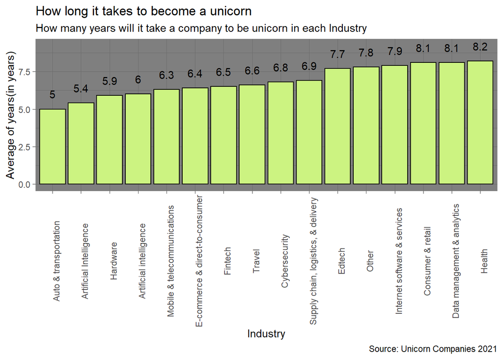

```r
# Getting a clear picture
ggplot(duration_Industry, aes(x=reorder(as.character(Industry),Avg.year), y=Avg.year)) +
  geom_col(fill="#CCF381",color = "black")+
  labs(title="How long it takes to become a unicorn",
       subtitle = "How many years will it take a company to be unicorn in each Industry",
       caption="Source: Unicorn Companies 2021",
       x="Industry",
       y="Average of years(in years)")+
  geom_text(aes(label=signif(Avg.year)),nudge_y = 1)+
  theme_dark()+
  theme(axis.text.x = element_text(angle = 90))
```

The chart above shows how long it takes for a company in a specific industry to become a unicorn.

Is this how it has always been? No, according to our above analysis, the average time it takes for a company to become a unicorn has decreased to 6.41 years since 2001, from over 23 years previously. To go deeper and gain a better understanding of countries, industries, and cities, simply substitute the criteria you want in the groupby statement, and the mean (average) of the duration (diffInYear) can be determined. When evaluating a potential investment, this information can help predict how long the investment will be profitable.

3. Which countries have the most unicorns? Are there any cities that appear to be industry hubs?

Let us now determine where our primary focus will be, our market. Wants to understand. Now we’ll see how many unicorns come from each country to determine where our main focus will be placed.

```r
#Change Hong kong to China in region
Unicorn_Companies<-mutate(Unicorn_Companies, Country = gsub("Hong Kong", "China",Unicorn_Companies$Country))

# Grouping to see how many unicorn from each country
CountryCount<-Unicorn_Companies%>%
  count(Country,name = "CountofCountry", sort = TRUE)%>%
  arrange(desc(CountofCountry))
head(CountryCount)
```

|  | Country | CountofCountry |
| --- | --- | --- |
| 1 | United States | 562 |
| 2 | China | 179 |
| 3 | India | 65 |
| 4 | United Kingdom | 43 |
| 5 | Germany | 26 |
| 6 | France | 24 |

From 1919 to 2021, the top six countries in terms of unicorn births were the United States, China, India, the United Kingdom, Germany, and France. With more information, we can select the best market for Polarity Ventures..

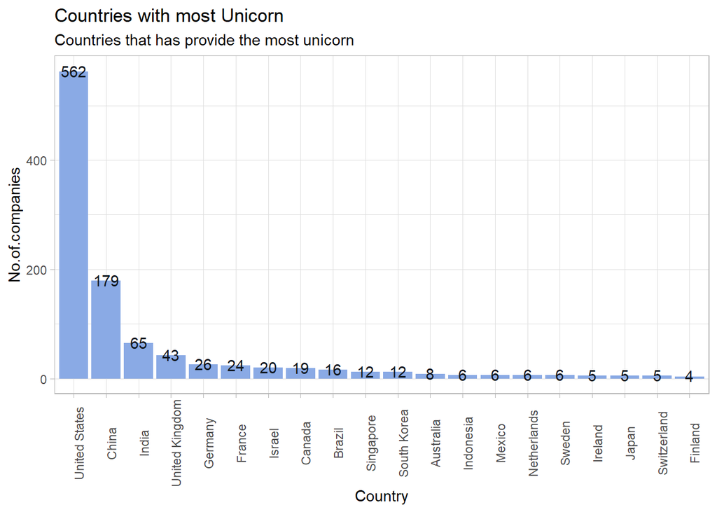

```r
#Top 20 countries
Top.20.countries<-CountryCount[1:20,]

# How many unicorns each Country have provided
ggplot(Top.20.countries,aes(x= reorder(Country,-CountofCountry),y= CountofCountry))+
  geom_col(fill="#8AAAE5")+
  labs(title = "Countries with most Unicorn",
       subtitle = "Countries that has provide the most unicorn",
       x= "Country",
       y= "No.of.companies")+
  geom_text(aes(label=signif(CountofCountry)), nudge_y = 1,color="#101820FF")+
  theme_light()+
  theme(axis.text.x = element_text(angle = 90))
```

The numbers of unicorns countries have provides, with United States being the country with the most unicorns and China following suits, now we can choose and focus on a region or regions as our market.

Are there any cities that appear to be industry hubs?

Narrowing into cities to make use of the information we have concerning cities unicorn has been coming from we can investigate to see if some cities have favours compared to others and if we should be looking out for those cities.

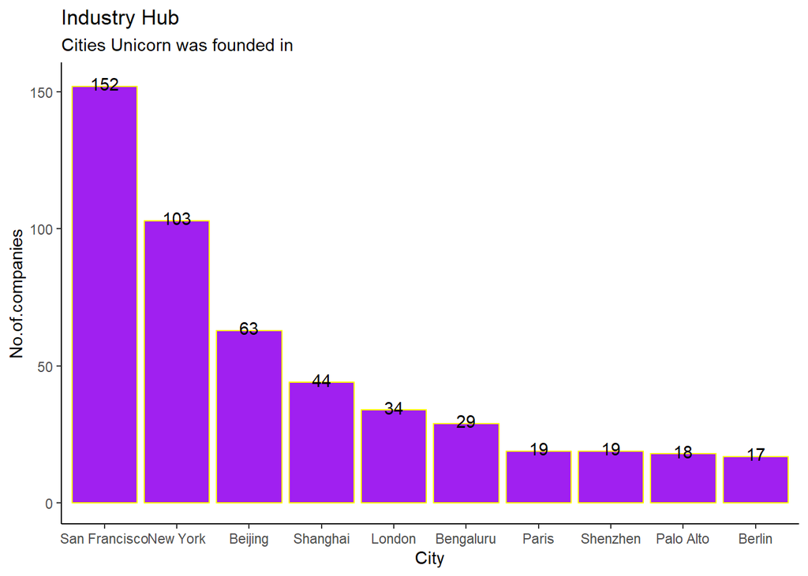

```r
#Top cities
CityCount<-Unicorn_Companies%>%
  count(City,name = "CountofCompany", sort = TRUE)%>%
  arrange(desc(CountofCompany))%>%
  mutate(CountofCompany2 = CountofCompany)%>%
  mutate(CountofCompany2 = as.character(CountofCompany2))

#Top 20 Cities with most unicorn
Top.Cities<-CityCount[1:10,]

# Presentation of the findings
ggplot(Top.Cities,aes(x=reorder(City,-CountofCompany),y=CountofCompany))+
  geom_col(color="yellow",fill= "purple")+
  labs(title = "Industry Hub",
       subtitle = "Cities Unicorn was founded in",
       x= "City",
       y= "No.of.companies")+
  geom_text(aes(label=signif(CountofCompany)),nudge_y = 1,color="black")+
  theme_classic()
```

4. Which investors have funded the most unicorns?

The last question is to figure out investors who have funded the most unicorn, this could be an added advantage for us at Polarity Ventures, using this information, going forward we can watch closely the which sector and companies this top investors are investing in and also making considerations of whether to go into business with them. In the unicorn data, the investors column holds the together all investors who funded a business. For us to get the top investors we will have to separate each investor distinctively.

```r
# Keeping columns we only need
Investors<-Unicorn_Companies%>%
  select(Company,Select_Investors)
Investors<-data.frame(Investors)

#separate the investors into 3 different columns
Investors<-transform(Investors,test=do.call(rbind,strsplit(Select_Investors,",", fixed = TRUE)), stringsAsFactors = F)
head(Investors)
```

|  | Company | Select_Investors | test.1 | test.2 | test.3 | test.4 |
| --- | --- | --- | --- | --- | --- | --- |
| 1 | Bytedance | Sequoia Capital China, SIG Asia Investments, Sina Weibo, Softbank Group | Sequoia Capital China | SIG Asia Investments | Sina Weibo | Softbank Group |
| 2 | SpaceX | Founders Fund, Draper Fisher Jurvetson, Rothenberg Ventures | Founders Fund | Draper Fisher Jurvetson | Rothenberg Ventures | Founders Fund |
| 3 | SHEIN | Tiger Global Management, Sequoia Capital China, Shunwei Capital Partners | Tiger Global Management | Sequoia Capital China | Shunwei Capital Partners | Tiger Global Management |
| 4 | Stripe | Khosla Ventures, LowercaseCapital, capitalG | Khosla Ventures | LowercaseCapital | capitalG | Khosla Ventures |
| 5 | Klarna | Institutional Venture Partners, Sequoia Capital, General Atlantic | Institutional Venture Partners | Sequoia Capital | General Atlantic | Institutional Venture Partners |
| 6 | Canva | Sequoia Capital China, Blackbird Ventures, Matrix Partners | Sequoia Capital China | Blackbird Ventures | Matrix Partners | Sequoia Capital China |

Now that our investors have been separated, we’ll remove the original investors column and any other columns that aren’t relevant to this analysis so that it doesn’t affect our results. And combining the separate columns into one column so that we only have one column for investors. Most companies had three investors, but few had four, so when we split the investors columns, companies with three investors were automatically filled in the fourth column with the first investor before the comma (test.4)

```r
#remove other columns and combine remaining columns into one
Investors<-subset(Investors,select = -Select_Investors)

#Remove the fourth column
Investors<-subset(Investors,select = -test.4)

# here we'll fix in the investors of the companies with four investors manually
Investors$test5<-ifelse(Investors$Company=="Bytedance","Softbank Group","")
Investors$test5<-ifelse(Investors$Company=="Niantic","Spark Capital",Investors$test5)
Investors$test5<-ifelse(Investors$Company=="Rappi","Redpoint e.ventures",Investors$test5)
Investors$test5<-ifelse(Investors$Company=="Yixia","Redpoint ventures",Investors$test5)
Investors$test5<-ifelse(Investors$Company=="Lightricks","Goldman Sachs",Investors$test5)

# Stacking the investors into one column
Investors<-Investors%>%
  cbind(Investors[1],stack(Investors[2:5]))
# Removing columns
drop<-c("test.1","test.2","test.3","test.4","ind","test5")
Investors<-Investors[,!(names(Investors)%in%drop)]
Investors<-subset(Investors,select = -Company)

# Renaming Columns
Investors<-rename(Investors,Investors = values, Company=Company.1)

# Trimming white spaces
Investors<-Investors%>%
  mutate_all(str_trim)

#Removing duplicates, that came about because of split and stack process.
Investors<-distinct(Investors,Company,Investors, .keep_all = TRUE)

#Top investors
Investors.count<-Investors%>%
  group_by(Investors)%>%
  count(Investors, name = "no.of.investment", sort = TRUE)%>%
  mutate(investments = as.character(no.of.investment))

#remove the row of the investor without a name
Investors.count<-Investors.count[-1,]

# Top 15 investors
Top.15.Investors<-Investors.count[1:15,]

head(Top.15.Investors)
```

| Investors | no.of.investment | investments |
| --- | --- | --- |
| Accel | 59 | 59 |
| Tiger Global Management | 53 | 53 |
| Andreessen Horowitz | 52 | 52 |
| Sequoia Capital China | 48 | 48 |
| Insight Partners | 47 | 47 |
| Sequoia Capital | 47 | 47 |

We have now successfully obtained our Top investors from 1919 to 2021, thus the timeline of this data. Accel on top with 59 unicorn investments, a fantastic achievement, and Tiger Global management following suit with 53 investments. Putting everything together, we’ll make a chart to help us understand the codes and numbers.

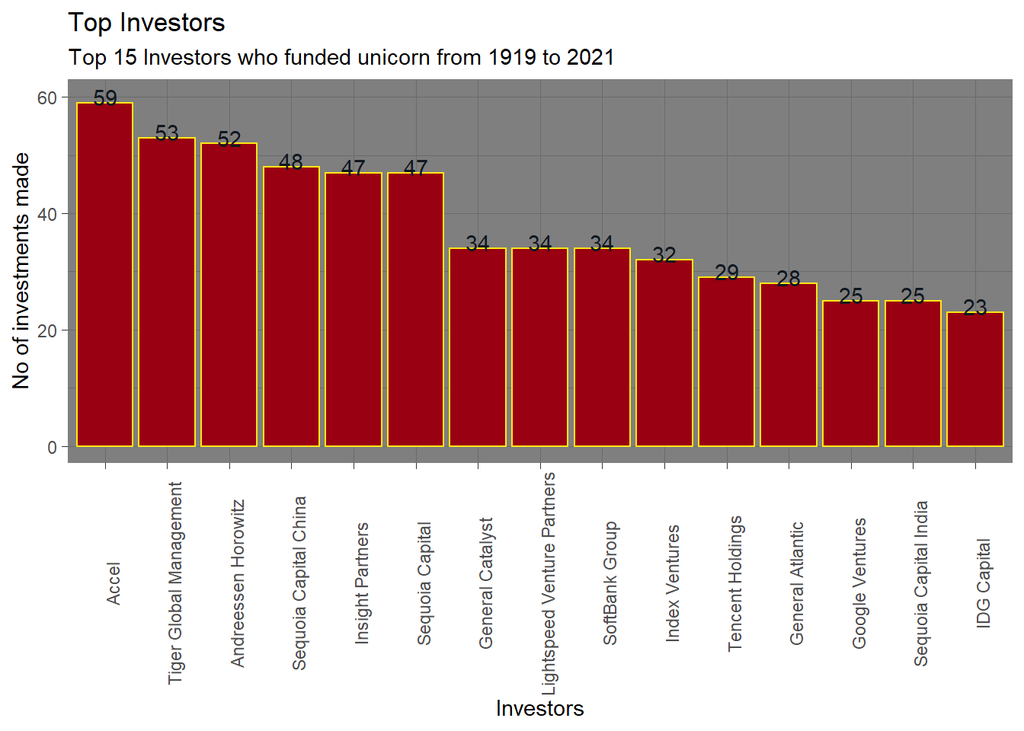

```r
#Presenting the results in more suitable manner
ggplot(Top.15.Investors,aes(x= reorder(Investors,-no.of.investment),y= no.of.investment))+
  geom_col(fill="#990011FF",color="#FEE715FF")+
  labs(title= "Top Investors",
       subtitle= "Top 15 Investors who funded unicorn from 1919 to 2021",
       x= "Investors",
       y= "No of investments made")+
  geom_text(aes(label=signif(no.of.investment)),nudge_y = 1,color="#101820FF")+
  theme_dark()+
  theme(axis.text.x = element_text(angle = 90))
```

Polarity Ventures can successfully navigate the venture capital business with the results of this analysis, meeting the goal of targeting small businesses or start-ups with the potential to become unicorns. However, the information contained in this data (unicorn companies) is insufficient to predict whether a company will become a unicorn; much more information will be required to reach such conclusions; the result of this analysis, to some extent, provides an idea in meeting Polarity Ventures’ goal.

```
                                  Insights
```

Finally, all of the questions posed for this analysis were duly addressed by; 1. Zappier had the highest return on investment, with a ROI of 399900%, which is an excellent return on investment.